# COS60008 Introduction to Data Science

## Assignment 3

## Student Details:

- Name: Kan Asvasena
- Student ID:
- Email:
- Submission Date: 23 June 2023
- TuteLab Class:

## Task 2 – Exploration

### Import Dependencies, Settings, and Load Data

```python
import pandas as pd
import numpy as np
import matplotlib.pyplot as plt
import matplotlib.ticker as ticker
import seaborn as sns

pd.set_option('display.max_colwidth', None)
%config InlineBackend.figure_format='retina'

data = pd.read_csv('../data/processed/clean_data.csv')
```

### Checking

```python
data.info()
```

```
<class 'pandas.core.frame.DataFrame'>
RangeIndex: 120 entries, 0 to 119
Data columns (total 13 columns):
 #   Column           Non-Null Count  Dtype
---  ------           --------------  -----
 0   Year             120 non-null    int64
 1   Location         120 non-null    object
 2   Avg Min Temp *C  120 non-null    float64
 3   Yr Rain mm       120 non-null    float64
 4   Heat Wave        120 non-null    object
 5   Dry Spell        120 non-null    object
 6   Cold Wave        120 non-null    object
 7   Wet Spell        120 non-null    object
 8   Irrigation       120 non-null    object
 9   Crop Type        120 non-null    object
 10  Crop Damage      120 non-null    object
 11  Yield            120 non-null    float64
 12  Observer         120 non-null    object
dtypes: float64(3), int64(1), object(9)
memory usage: 12.3+ KB
```

```python
data.head(10)
```

|  | Year | Location | Avg Min Temp *C | Yr Rain mm | Heat Wave | Dry Spell | Cold Wave | Wet Spell | Irrigation | Crop Type | Crop Damage | Yield | Observer |
| --- | --- | --- | --- | --- | --- | --- | --- | --- | --- | --- | --- | --- | --- |
| 0 | 1980 | Emilyland | 19.6 | 707.94118 | No | No | Yes | No | Yes | Wheat | Yes | 1287.55 | Ryan Stewart |
| 1 | 1980 | East Xavierport | 23.0 | 615.49026 | No | No | Yes | No | Yes | Wheat | Yes | 1426.41 | Tracie Bell |
| 2 | 1980 | North Daniel | 21.0 | 1230.83066 | No | No | No | No | No | Maize | No | 796.92 | Thomas Miller |
| 3 | 1981 | Emilyland | 19.9 | 852.34018 | No | No | Yes | No | Yes | Wheat | Yes | 1305.04 | Sara Nguyen |
| 4 | 1981 | East Xavierport | 23.2 | 591.44154 | No | No | Yes | No | Yes | Maize | Yes | 1031.42 | Tracie Bell |
| 5 | 1981 | North Daniel | 21.0 | 1337.11950 | No | No | No | No | No | Soy | No | 1497.04 | Tammy Calderon |
| 6 | 1982 | Emilyland | 19.9 | 762.67056 | No | No | Yes | No | Yes | Soy | Yes | 1601.38 | Sara Nguyen |
| 7 | 1982 | East Xavierport | 23.1 | 678.40098 | No | No | Yes | No | Yes | Soy | Yes | 1727.60 | Amanda Reed |
| 8 | 1982 | North Daniel | 21.1 | 1378.86186 | No | No | No | No | No | Soy | No | 1496.62 | Kevin Henry |
| 9 | 1983 | Emilyland | 20.3 | 810.13046 | No | No | Yes | No | Yes | Maize | Yes | 923.89 | Sara Nguyen |

### 2.1 Baseline Properties & Count Questions (Answer All. ~20 marks, ~1 mark each)

#### 2.1.1 Determine the following basic details about the data. (Presented as a table would be ideal, but not required):

1. What is the “Year” range (max, min) of the data collected?
2. Are there any missing years in the data? If so, which?
3. What are the “Locations” (values) in the data?
4. What are the “Crop Types” (values) in the data?
5. What is the range (min, max) of the temperature values?
6. What is the range (min, max) of the rainfall values?

```python
basic_details = pd.DataFrame({
    'Basic Detail': ['Year Range', 'Missing Year', 'Location', 'Crop Types', 'Temperature Range (°C)', 'Rainfall Range (mm)'],
    'Value': [
        f"{data['Year'].min()} - {data['Year'].max()}",
        "No" if set(range(1980, 2020)) == set(data['Year'].unique()) else "Yes",
        ', '.join(data['Location'].unique()),
        ', '.join(data['Crop Type'].unique()),
        f"{data['Avg Min Temp *C'].min()} - {data['Avg Min Temp *C'].max()}",
        f"{data['Yr Rain mm'].min():.2f} - {data['Yr Rain mm'].max()}"
    ]
})

basic_details.index += 1
basic_details
```

|  | Basic Detail | Value |
| --- | --- | --- |
| 1 | Year Range | 1980 - 2019 |
| 2 | Missing Year | No |
| 3 | Location | Emilyland, East Xavierport, North Daniel |
| 4 | Crop Types | Wheat, Maize, Soy |
| 5 | Temperature Range (°C) | 19.6 - 25.3 |
| 6 | Rainfall Range (mm) | 591.44 - 2097.95 |

#### 2.1.2 Have all locations been used every year of data collection?

```python
"Yes, they have." if (data.groupby('Year')['Location'].nunique() == data['Location'].nunique()).all else "No, they have not."
```

```
'Yes, they have.'
```

#### 2.1.3 Do locations always have the same “Irrigated” value or does it change over the years?

```python
pivot_df = data.pivot(index='Year', columns='Location', values='Irrigation')

for location in pivot_df.columns:
    unique_values = pivot_df[location].unique()
    if len(unique_values) > 1:
        print(f"'{location}' has more than one unique value for 'Irrigation', which are '{unique_values}'")
    else:
        print(f"'{location}' has only one unique value for 'Irrigation', which is '{unique_values[0]}'")
```

```
'East Xavierport' has only one unique value for 'Irrigation', which is 'Yes'
'Emilyland' has only one unique value for 'Irrigation', which is 'Yes'
'North Daniel' has only one unique value for 'Irrigation', which is 'No'
```

**Answer**: Yes, all locations always have the same 'Irrigation' value

#### 2.1.4 What is the total number of valid data entries (rows of data) you are expecting based on years of data collected and number of site locations?

Is this the number you actually have? If not, why?

```python
expected_rows = len(data['Year'].unique()) * len(data['Location'].unique())
actual_rows = data.shape[0]

print(f"Expected number of rows based on years of data collected and number of locations: {expected_rows}")
print(f"Actual number of rows: {actual_rows}")
print(f"Are they equal?: {'Yes' if expected_rows == actual_rows else 'No'}")
```

```
Expected number of rows based on years of data collected and number of locations: 120
Actual number of rows: 120
Are they equal?: Yes
```

#### 2.1.5 Explore the “Crop” data:

1. What is the total occurrence (count used) of each crop type in the sample? (Table?)

```python
df_crop_type = data.groupby('Crop Type')['Crop Type'].count().reset_index(name='Count')
df_crop_type.sort_values(by='Count', ascending=False, inplace=True)
df_crop_type
```

|  | Crop Type | Count |
| --- | --- | --- |
| 1 | Soy | 46 |
| 0 | Maize | 37 |
| 2 | Wheat | 37 |

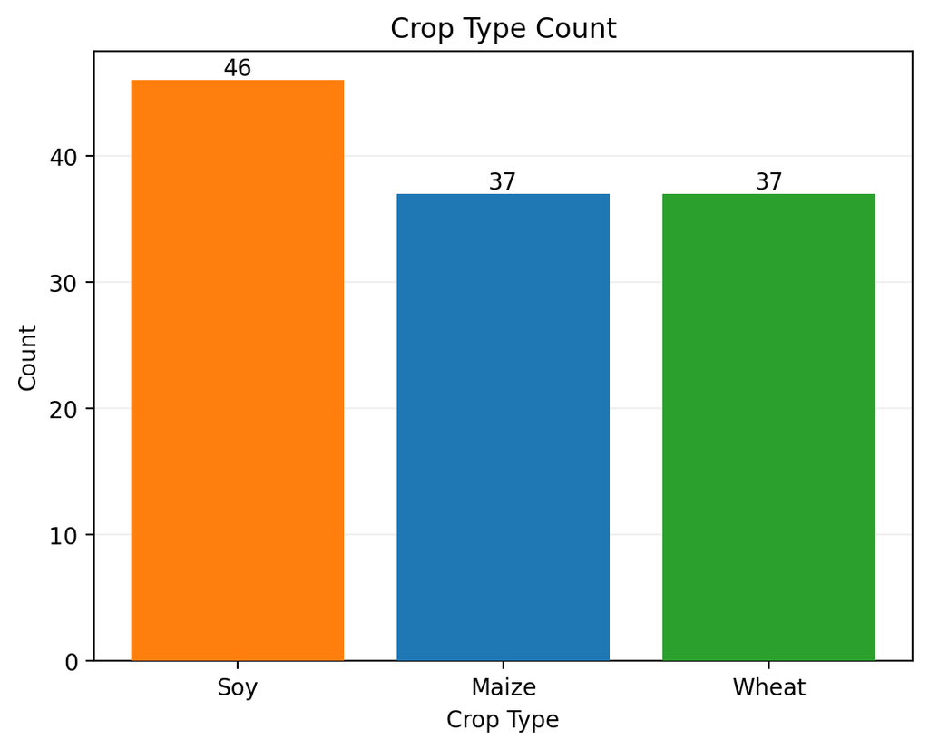

```python
# plot the dataframe to a bar chart
color_map = {
    'Soy': (1.0, 0.4980392156862745, 0.054901960784313725),
    'Maize': (0.12156862745098039, 0.4666666666666667, 0.7058823529411765),
    'Wheat': (0.17254901960784313, 0.6274509803921569, 0.17254901960784313),
}
colors = [color_map[crop] for crop in df_crop_type['Crop Type']]

bars = plt.bar(df_crop_type['Crop Type'], df_crop_type['Count'], color=colors, zorder=3)
plt.title('Crop Type Count')
plt.xlabel('Crop Type')
plt.ylabel('Count')
plt.grid(axis='y', zorder=10, alpha=0.2)
for bar in bars:
    yval = bar.get_height()
    plt.text(bar.get_x() + bar.get_width() / 2, yval, round(yval, 2), ha='center', va='bottom')
plt.show()
```

2. What is the break-down (count used) of “crop type” at each location? (Plot? Table?)

```python
df_crop_location = data.groupby(['Location', 'Crop Type']).size().reset_index(name='Count')

pivot_df = df_crop_location.pivot(index='Location', columns='Crop Type', values='Count')
pivot_df
```

| Crop Type Location | Maize | Soy | Wheat |
| --- | --- | --- | --- |
| East Xavierport | 10 | 18 | 12 |
| Emilyland | 12 | 16 | 12 |
| North Daniel | 15 | 12 | 13 |

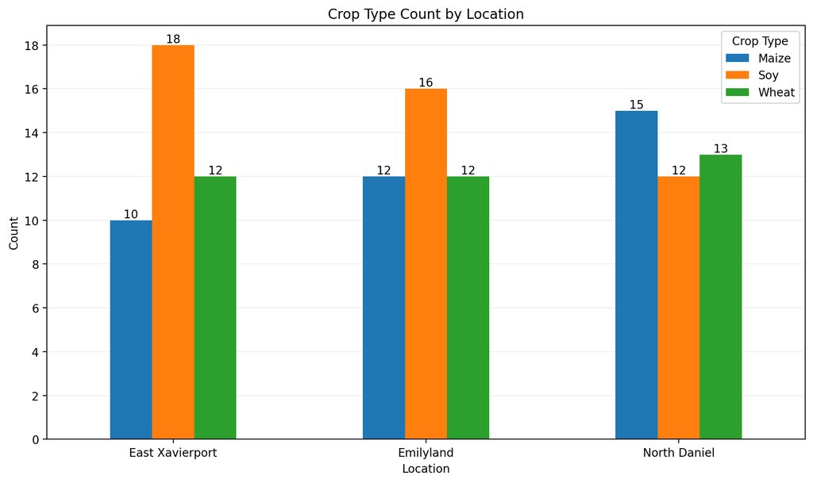

```python
# plot the dataframe to a bar chart
ax = pivot_df.plot(kind='bar', figsize=(10, 6), color=plt.cm.tab10.colors, zorder=2)
plt.title('Crop Type Count by Location')
plt.xlabel('Location')
plt.ylabel('Count')
plt.xticks(rotation=0)
plt.yticks(np.arange(0, 19, 2))
plt.grid(axis='y', zorder=10, alpha=0.2)
for container in ax.containers:
    ax.bar_label(container)
plt.tight_layout()
plt.show()
```

3. What is the total yield for each crop type over the entire sample? (Yield total by type?)

```python
df_total_yield = data.groupby('Crop Type')['Yield'].sum().reset_index()
df_total_yield = df_total_yield.rename(columns={'Yield': 'Total Yield'})
df_total_yield.sort_values(by='Total Yield', ascending=False, inplace=True)
df_total_yield
```

|  | Crop Type | Total Yield |
| --- | --- | --- |
| 1 | Soy | 75907.25 |
| 2 | Wheat | 49032.99 |
| 0 | Maize | 33872.80 |

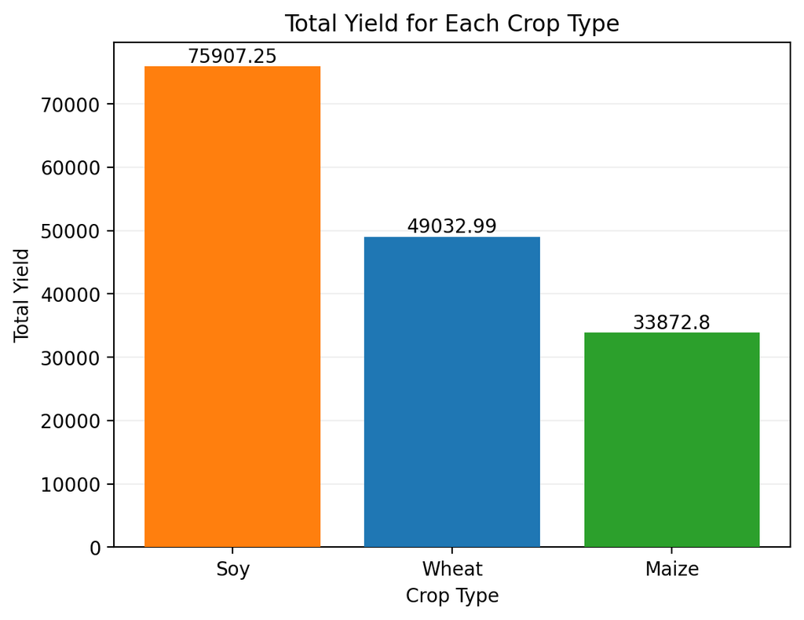

```python
# plot the dataframe to a bar chart
bars = plt.bar(df_total_yield['Crop Type'], df_total_yield['Total Yield'], color=colors, zorder=3)
plt.title('Total Yield for Each Crop Type')
plt.xlabel('Crop Type')
plt.ylabel('Total Yield')
plt.grid(axis='y', zorder=10, alpha=0.2)
for bar in bars:
    yval = bar.get_height()
    plt.text(bar.get_x() + bar.get_width() / 2, yval, round(yval, 2), ha='center', va='bottom')
plt.show()
```

4. Has there been any changes in crop type usage over time? (Trends? Uniform? Plot?)

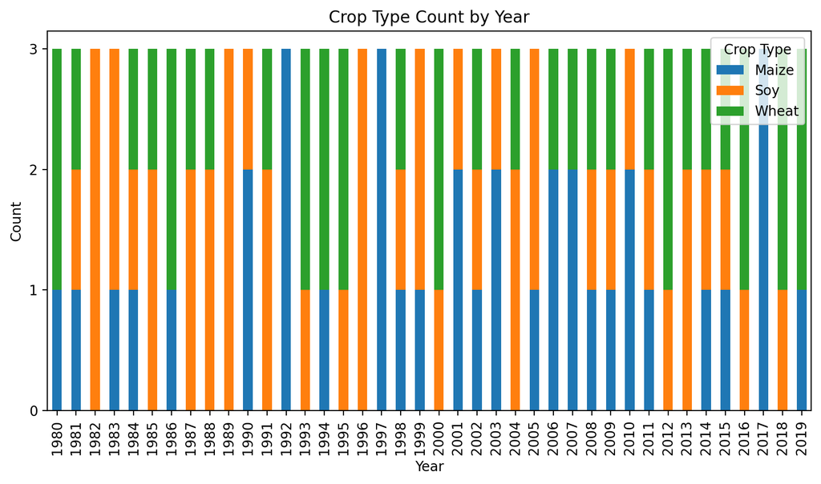

```python
pivot = data.groupby(['Year', 'Crop Type']).size().unstack()

fig, ax = plt.subplots(figsize=(10, 5))
pivot.plot(kind='bar', stacked=True, ax=ax)
ax.get_yaxis().set_major_formatter(ticker.FuncFormatter(lambda x, p: format(int(x), ',')))
plt.ylabel('Count')
plt.yticks([0,1,2,3])
plt.title('Crop Type Count by Year')
plt.show()
```

According to the 'Crop Type Count by Year' stacked bar chart, there was no obvious trend in changing crop types.

#### 2.1.6 Staff members making obversions

- Who was the longest serving staff member(s) making observations?
  - How many years and at what location?
- Did any staff member join again after they first performed the role?

```python
# Group by Observer and find the minimum and maximum year for each Observer
observer_years = data.groupby('Observer')['Year'].agg(['min', 'max'])

# Calculate the range of years for each Observer
observer_years['year range'] = observer_years['max'] - observer_years['min']

# Find the maximum range
max_range = observer_years['year range'].max()

# Find the Observers with the maximum range
longest_serving_observers = observer_years[observer_years['year range'] == max_range]

observer_locations = data.groupby('Observer')['Location'].agg(lambda x:x.value_counts().index[0])
longest_serving_observers = pd.merge(longest_serving_observers, observer_locations, left_index=True, right_index=True)
longest_serving_observers = longest_serving_observers.rename(columns={"min": "start", "max": "end"})

print('The longest serving staff members:')
longest_serving_observers
```

```
The longest serving staff members:
```

| Observer | start | end | year range | Location |
| --- | --- | --- | --- | --- |
| Jennifer Patel | 1986 | 1989 | 3 | East Xavierport |
| Sara Nguyen | 1981 | 1984 | 3 | Emilyland |
| Summer Hobbs | 2012 | 2015 | 3 | Emilyland |
| Tiffany Decker | 1995 | 1998 | 3 | Emilyland |

```python
# Group data by Observer and Year and check if the difference between consecutive years is more than 1
data_sorted = data.sort_values(by='Year')
gaps = data_sorted.groupby('Observer')['Year'].diff() > 1

# Find any observers with gaps
observers_with_gaps = data_sorted[gaps]['Observer'].unique()

if observers_with_gaps.size > 0:
    print(f'Observers who joined again after they first performed the role: {", ".join(observers_with_gaps)}')
else:
    print('Observers who joined again after they first performed the role: None')
```

```
Observers who joined again after they first performed the role: None
```

### 2.2 General Relationships (~2-5 marks each):

#### 2.2.1 Is there a relationship between temperature and yield? (Consider “in general” is acceptable.)

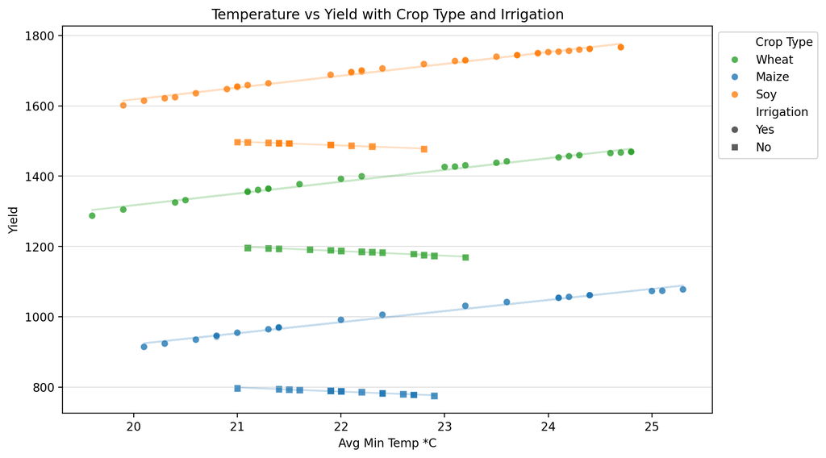

```python
# Create a dictionary mapping Crop Type to color
color_map = {
    'Soy': (1.0, 0.4980392156862745, 0.054901960784313725),
    'Maize': (0.12156862745098039, 0.4666666666666667, 0.7058823529411765),
    'Wheat': (0.17254901960784313, 0.6274509803921569, 0.17254901960784313),
}
# Define marker shapes for irrigation categories
marker_map = {'Yes': 'o', 'No': 's'}

# Create an empty plot
plt.figure(figsize=(10, 6))

# Create a scatter plot for each Crop Type and each Irrigation category
sns.scatterplot(data=data, x='Avg Min Temp *C', y='Yield', hue='Crop Type', style='Irrigation', palette=color_map, markers=marker_map, alpha=0.8)

# Add trend lines
for crop in data['Crop Type'].unique():
    for location in data['Irrigation'].unique():
        subset = data[(data['Crop Type'] == crop) & (data['Irrigation'] == location)]
        if not subset.empty:  # Ensure there is data for this combination
            z = np.polyfit(subset['Avg Min Temp *C'], subset['Yield'], 1)  # Fit a line
            p = np.poly1d(z)  # Create a function for the line
            plt.plot(subset['Avg Min Temp *C'], p(subset['Avg Min Temp *C']), color=color_map[crop], alpha=0.25)  # Plot the line

plt.title('Temperature vs Yield with Crop Type and Irrigation')

# Get the current axes
ax = plt.gca()

# Get the handles and labels for the figure
handles, labels = ax.get_legend_handles_labels()

# Create a custom legend
ax.legend(handles=handles[1:], labels=labels[1:], title="Legend", title_fontsize='13', loc='upper right')
plt.legend(bbox_to_anchor=(1,1))
plt.grid(axis='y', zorder=10, alpha=0.4)
plt.show()
```

The "Temperature vs Yield with Crop Type and Irrigation" scatter plot reveals two trends for all crop types:

- First, as the temperature increased, the yield from irrigated locations moderately increased.
- In contrast, with higher temperatures, the yield from non-irrigated locations slightly decreased.

#### 2.2.2 Is there a relationship between rainfall and yield? (Consider “in general” is acceptable.)

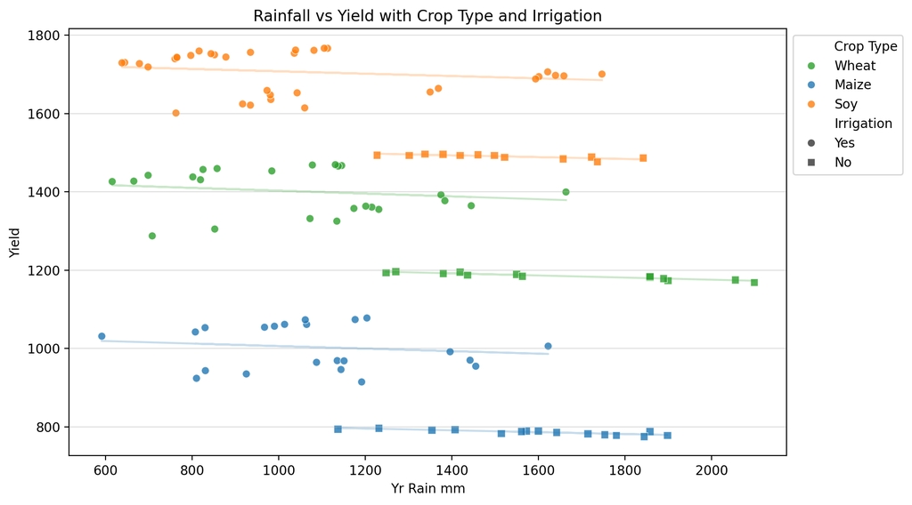

```python
# Define marker shapes for irrigation categories
marker_map = {'Yes': 'o', 'No': 's'}

# Create an empty plot
plt.figure(figsize=(10, 6))

# Create a scatter plot for each Crop Type and each Irrigation category
sns.scatterplot(data=data, x='Yr Rain mm', y='Yield', hue='Crop Type', style='Irrigation', palette=color_map, markers=marker_map, alpha=0.8)

# Add trend lines
for crop in data['Crop Type'].unique():
    for location in data['Irrigation'].unique():
        subset = data[(data['Crop Type'] == crop) & (data['Irrigation'] == location)]
        if not subset.empty:  # Ensure there is data for this combination
            z = np.polyfit(subset['Yr Rain mm'], subset['Yield'], 1)  # Fit a line
            p = np.poly1d(z)  # Create a function for the line
            plt.plot(subset['Yr Rain mm'], p(subset['Yr Rain mm']), color=color_map[crop], alpha=0.25)  # Plot the line

plt.title('Rainfall vs Yield with Crop Type and Irrigation')

# Get the current axes
ax = plt.gca()

# Get the handles and labels for the figure
handles, labels = ax.get_legend_handles_labels()

# Create a custom legend
ax.legend(handles=handles[1:], labels=labels[1:], title="Legend", title_fontsize='13', loc='upper right')
plt.legend(bbox_to_anchor=(1,1), loc=2)
plt.grid(axis='y', zorder=10, alpha=0.4)
plt.show()
```

The scatter plot 'Rainfall vs Yield with Crop Type and Irrigation' reveals that, across all crop types and irrespective of irrigation, there is a slight decrease in yield as rainfall increases."

#### 2.2.3 Is there a difference in yield expectations for specific crop types?

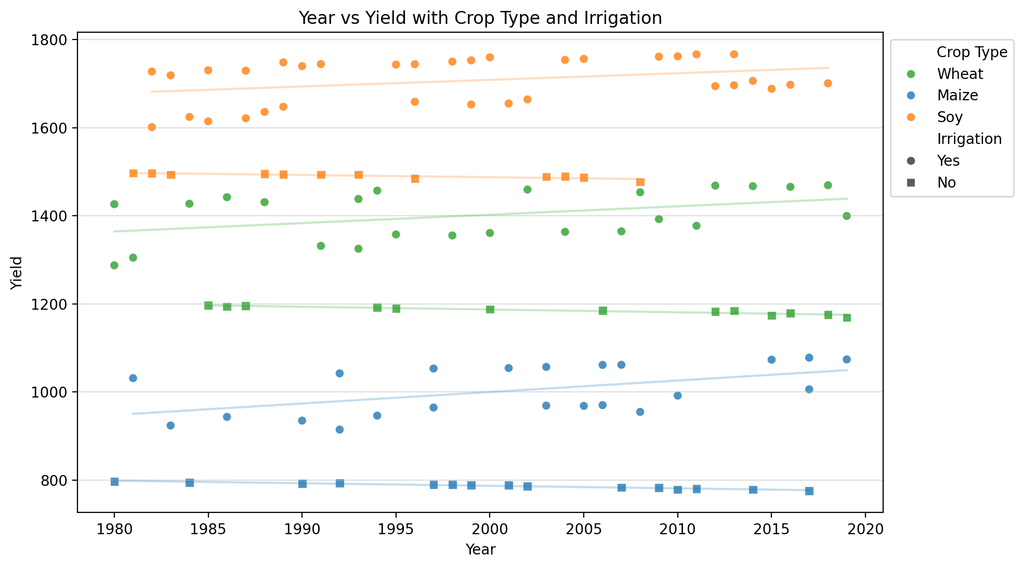

```python
# Define marker shapes for irrigation categories
marker_map = {'Yes': 'o', 'No': 's'}  # 's' for square (irrigated), 'o' for circle (not irrigated)

# Create an empty plot
plt.figure(figsize=(10, 6))

# Create a scatter plot for each Crop Type and each Irrigation category
sns.scatterplot(data=data, x='Year', y='Yield', hue='Crop Type', style='Irrigation', palette=color_map, markers=marker_map, alpha=0.8)

# Add trend lines
for crop in data['Crop Type'].unique():
    for location in data['Irrigation'].unique():
        subset = data[(data['Crop Type'] == crop) & (data['Irrigation'] == location)]
        if not subset.empty:  # Ensure there is data for this combination
            z = np.polyfit(subset['Year'], subset['Yield'], 1)  # Fit a line
            p = np.poly1d(z)  # Create a function for the line
            plt.plot(subset['Year'], p(subset['Year']), color=color_map[crop], alpha=0.25)  # Plot the line

plt.title('Year vs Yield with Crop Type and Irrigation')

# Get the current axes
ax = plt.gca()

# Get the handles and labels for the figure
handles, labels = ax.get_legend_handles_labels()

# Create a custom legend
ax.legend(handles=handles[1:], labels=labels[1:], title="Legend", title_fontsize='13', loc='upper right')
plt.legend(bbox_to_anchor=(1,1), loc=2)
plt.grid(axis='y', zorder=10, alpha=0.4)
plt.show()
```

The 'Year vs Yield with Crop Type and Irrigation' scatter plot shows two trends for all crops:

- As the years progressed, the yield from irrigated locations moderately increased.
- In contrast, the yield from non-irrigated locations exhibited a slight decrease over time.

#### 2.2.4 Is there a difference in yield trends (over time) at different locations?

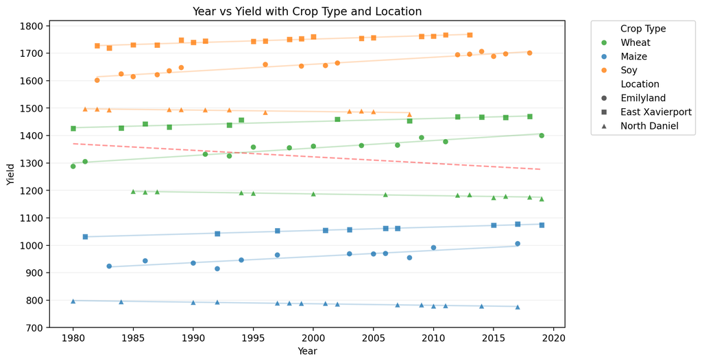

```python
# Define marker shapes for each location
locations = data['Location'].unique()
markers = ['o', 's', '^']
marker_map = {location: marker for location, marker in zip(locations, markers)}

# Create an empty plot
plt.figure(figsize=(10, 6))

# Create a scatter plot for each Crop Type and each Location
sns.scatterplot(data=data, x='Year', y='Yield', hue='Crop Type', style='Location', palette=color_map, markers=marker_map, alpha=0.8)

# Add trend lines
for crop in data['Crop Type'].unique():
    for location in data['Location'].unique():
        subset = data[(data['Crop Type'] == crop) & (data['Location'] == location)]
        if not subset.empty:  # Ensure there is data for this combination
            z = np.polyfit(subset['Year'], subset['Yield'], 1)  # Fit a line
            p = np.poly1d(z)  # Create a function for the line
            plt.plot(subset['Year'], p(subset['Year']), color=color_map[crop], alpha=0.25)  # Plot the line

plt.title('Year vs Yield with Crop Type and Location')

# Calculate the trendline
z = np.polyfit(data['Year'], data['Yield'], 1)
p = np.poly1d(z)
# Plot the trendline
plt.plot(data['Year'], p(data['Year']), "r--", alpha=0.4)

# Get the current axes
ax = plt.gca()

# Get the handles and labels for the figure
handles, labels = ax.get_legend_handles_labels()

# Create a custom legend
legend = ax.legend(handles=handles[1:], labels=labels[1:], title="Legend", title_fontsize='13', loc='upper right')

# Put a legend to the right of the current axis
plt.legend(bbox_to_anchor=(1.05, 1), loc=2, borderaxespad=0.)
plt.grid(axis='y', zorder=10, alpha=0.2)
plt.yticks(np.arange(700, 1900, 100))

plt.show()
```

The 'Year vs Yield with Crop Type and Location' scatter plot reveals three trends:

1. As the years progressed, crop yields in irrigated locations, 'Emilyland' and 'East Xavierport', increased.
2. In contrast, in non-irrigated location, 'North Daniel', saw a slight decrease in crop yield over the same period.
3. The average trend line (red line) indicates a decline due to reduced production of the high-yield crop which is soy.

#### 2.2.5 What is the location that has performed best over the entire collection time?

```python
# Group the data by location and sum the yields
total_yields = data.groupby('Location')['Yield'].sum()

# Get the location with the highest total yield
best_location = total_yields.idxmax()

print(f"The location that has performed best over the entire collection time is: {best_location}")
```

```
The location that has performed best over the entire collection time is: East Xavierport
```

#### 2.2.6 What is the crop type that has performed best over the entire collection time?

```python
# Group the data by crop type and sum the yields
total_yields = data.groupby('Crop Type')['Yield'].sum()

# Get the crop type with the highest total yield
best_crop = total_yields.idxmax()

print(f"The crop type that has performed best over the entire collection time is: {best_crop}")
```

```
The crop type that has performed best over the entire collection time is: Soy
```

#### 2.2.7 Additional Data Exploration for Clearer Understanding

- Irrigated and Non-irrigated Locations

```python
# Group by 'Location' and 'Irrigation', count the instances, and reset the index
location_irrigation_counts = data.groupby(['Location', 'Irrigation']).size().reset_index(name='Count')

# Display the DataFrame
location_irrigation_counts
```

|  | Location | Irrigation | Count |
| --- | --- | --- | --- |
| 0 | East Xavierport | Yes | 40 |
| 1 | Emilyland | Yes | 40 |
| 2 | North Daniel | No | 40 |

North Daniel is the only non-irrigated location, whereas East Xavierport and Emilyland are irrigated.

- Year vs Rainfall with Locations

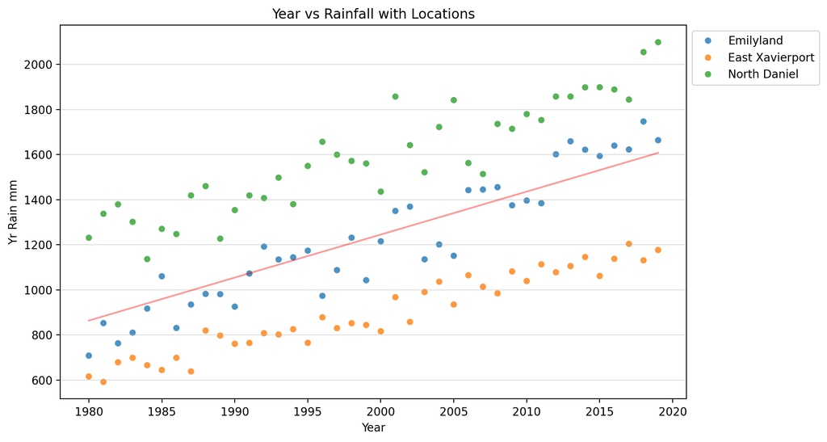

```python
# plot year vs rainfall
plt.figure(figsize=(10, 6))
sns.scatterplot(data=data, x='Year', y='Yr Rain mm', hue='Location', palette=plt.cm.tab10.colors, alpha=0.8)
plt.title('Year vs Rainfall with Locations')
plt.legend(bbox_to_anchor=(1,1), loc=2)
plt.grid(axis='y', zorder=10, alpha=0.4)

# Calculate the trendline
z = np.polyfit(data['Year'], data['Yr Rain mm'], 1)
p = np.poly1d(z)
# Plot the trendline
plt.plot(data['Year'], p(data['Year']), "r", alpha=0.4)

plt.show()
```

The 'Year vs Rainfall with Locations' scatter plot shows, as the years went by, the rainfall increased for all locations.

- Year vs Temperature

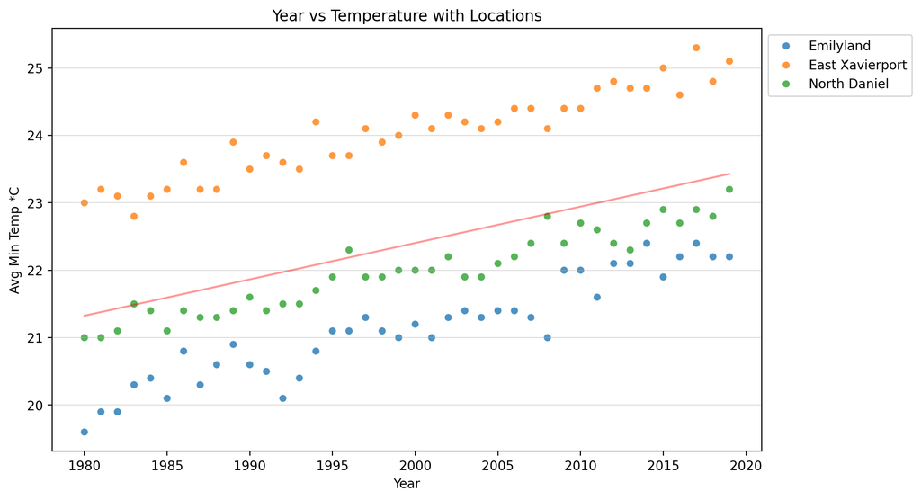

```python
# plot year vs rainfall
plt.figure(figsize=(10, 6))
sns.scatterplot(data=data, x='Year', y='Avg Min Temp *C', hue='Location', palette=plt.cm.tab10.colors, alpha=0.8)
plt.title('Year vs Temperature with Locations')
plt.legend(bbox_to_anchor=(1,1), loc=2)
plt.grid(axis='y', zorder=10, alpha=0.4)

# Calculate the trendline
z = np.polyfit(data['Year'], data['Avg Min Temp *C'], 1)
p = np.poly1d(z)
# Plot the trendline
plt.plot(data['Year'], p(data['Year']), "r", alpha=0.4)

plt.show()
```